# E013 Pho4 chimera activity analysis using PHO5 reporter, analysis

# Analysis

## Plotting functions

```r
source("../script/20240211-chimera-data-plotting-functions.R")
```

Source the scripts

```r
my_plot_ratio <- function(selection){
  # custom colors for this function
  date.colors = c(brewer.pal(name="Dark2", n = 8), brewer.pal(name="Paired", n = 8))
  host.colors = c("PHO2" = "gray30", "pho2" = "gray70")
  point.colors = c("PHO2" = "forestgreen", "pho2" = "purple4")
  # prepare data
  tmp <- my_data_prep(selection)
  # plotting
  p <- tmp %>%
    select(-c(FSC.H, nGFP, nRFP, flag)) %>%
    mutate(`R/G` = YL2.H/BL1.H) %>%
    pivot_longer(cols = c(BL1.H, YL2.H, `R/G`),
                 names_to = "parameter", values_to = "value") %>%
    mutate(parameter = factor(parameter, levels = c("R/G", "YL2.H", "BL1.H"),
                              labels = c("RFP/GFP", "PHO5pRFP", "Pho4-GFP"))) %>%
    ggplot(aes(x = symbol, y = value, group = host)) +
    stat_summary(aes(group = host), fun.data = "mean_cl_boot", geom = "errorbar",
                 position = position_dodge(0.5), width = 0.3) +
    geom_bar(aes(fill = host), width = 0.5, alpha = 0.8,
             stat = "summary", fun = "mean", position = position_dodge(0.5)) +
    geom_point(data = function(x) subset(x, !symbol %in% c("CCCCC", "SSSSS")),
               aes(group = host, color = date), size = 1, shape = 3, alpha = 0.9,
               position = position_jitterdodge(dodge.width = 0.5, jitter.width = 0.1)) +
    scale_color_manual(values = date.colors, guide = "none") +
    #geom_point(data = function(x) subset(x, !symbol %in% c("CCCCC", "SSSSS")),
    #           aes(group = host, color = host), size = 1, shape = 3, alpha = 0.9,
    #           position = position_jitterdodge(dodge.width = 0.5, jitter.width = 0.1)) +
    #scale_color_manual(values = point.colors) +
    scale_fill_manual(values = host.colors) +
    facet_grid(parameter~group, scales = "free", space = "free_x") +
    theme_bw(base_size = 18) + background_grid(minor = "none") +
    xlab("Pho4 chimera") +
    theme(axis.text.x = element_text(angle = 30, hjust = 1, family = "mono"),
          legend.position = "top",
          axis.title = element_blank())
  return(p)
}
```

Modify the component plotting function for special purposes

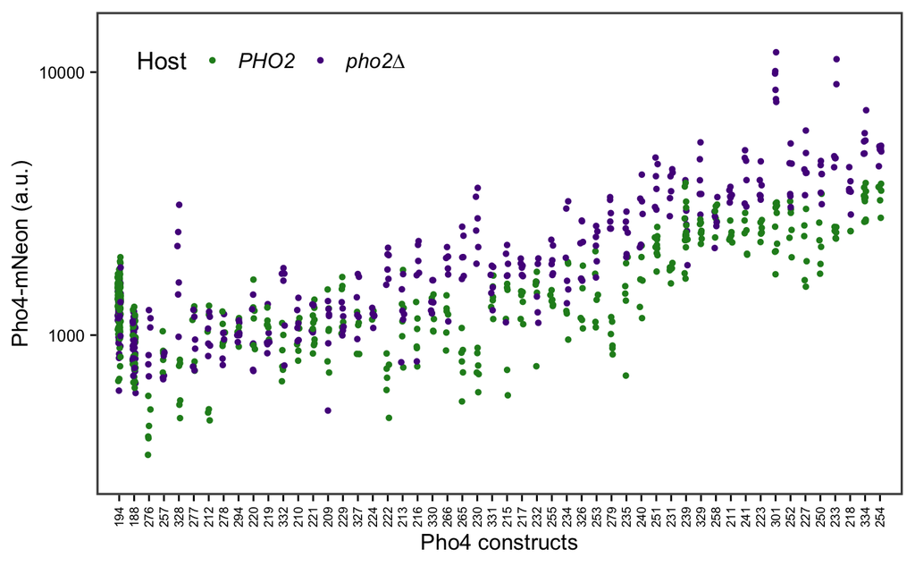

```r
host.labels = c("PHO2", "pho2∆")
point.colors = c("PHO2" = "forestgreen", "pho2" = "purple4")
p1 <- dat %>%
  filter(!is.na(plasmid)) %>%
  mutate(plasmid = fct_reorder(plasmid, BL1.H, .fun = median) %>%
           fct_relevel("194", "188")) %>%
  ggplot(aes(x = plasmid, y = BL1.H)) +
  geom_point(aes(color = host), position = position_jitter(0.1),
             size = 1.1) +
  scale_color_manual("Host", values = point.colors, labels = host.labels) +
  scale_y_log10(breaks = c(100, 1000, 10000), expand = expansion(mult = 0.1)) +
  scale_x_discrete(expand = expansion(mult = 0.03)) +
  xlab("Pho4 constructs") + ylab("Pho4-mNeon (a.u.)") +
  theme_cowplot() + panel_border(color = "gray30", size = 1.2) +
  theme(axis.text.x = element_text(angle = 90, size = rel(0.6), vjust = 0.5),
        axis.text.y = element_text(size = rel(0.8)),
        axis.title = element_text(size = rel(0.9)),
        axis.line = element_blank(),
        legend.position = c(0.05, 0.9),
        legend.direction = "horizontal",
        legend.text = element_text(face = 3))
p1
```

```r
#ggsave("../img/20240307-Pho4-chimera-protein-level-variation.png",
#       width = 6, height = 3)
```

## Pho4 chimera protein level variation

What is the distribution of Pho4 chimera protein levels? Is the mCherry/mNeon ratio a faithful measure of the chimera’s activities?

Distribution of Pho4-mNeon levels grouped by plasmid and host.

```r
tmp <- dat %>%
  filter(plasmid == "194", host == "PHO2")

lm <- lm(YL2.H ~ BL1.H, data = tmp)
summary(lm)
```

```
Call:
lm(formula = YL2.H ~ BL1.H, data = tmp)

Residuals:
    Min      1Q  Median      3Q     Max
-6194.6 -1651.7  -169.8  1417.1  6612.2

Coefficients:
             Estimate Std. Error t value Pr(>|t|)
(Intercept) 9562.8515  1114.3148   8.582 1.48e-14 ***
BL1.H         10.4668     0.7911  13.230  < 2e-16 ***
---
Signif. codes:  0 ‘***’ 0.001 ‘**’ 0.01 ‘*’ 0.05 ‘.’ 0.1 ‘ ’ 1

Residual standard error: 2284 on 142 degrees of freedom
Multiple R-squared:  0.5521,    Adjusted R-squared:  0.5489
F-statistic:   175 on 1 and 142 DF,  p-value: < 2.2e-16
```

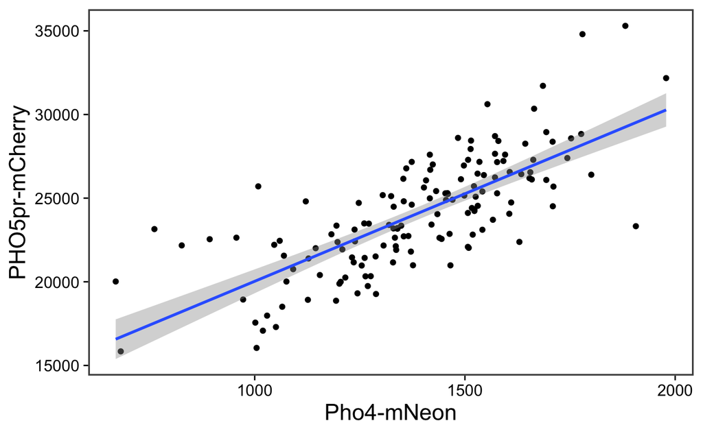

```r
p2 <- tmp %>%
  ggplot(aes(x = BL1.H, y = YL2.H)) +
  geom_point(size = 1.5) +
  stat_smooth(method = "lm", formula = y ~ x) +
  xlab("Pho4-mNeon") + ylab("PHO5pr-mCherry") +
  theme_cowplot() +
  panel_border(color = "gray30", size = 1.2) +
  theme(axis.line = element_blank(),
        axis.title = element_text(size = rel(1.2))
  )

p2
ggsave("../img/20240307-ScPho4-mCherry-vs-mNeon-consistent.png",
       width = 4, height = 3.5)
```

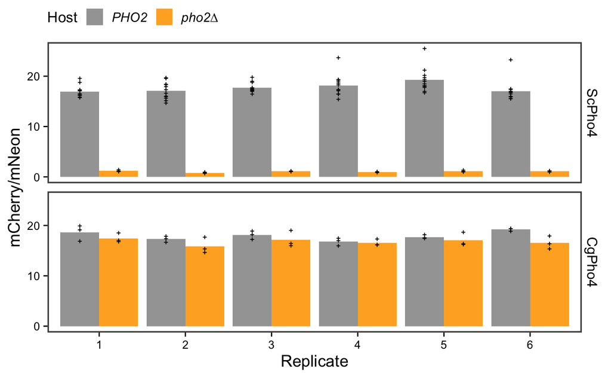

```r
host.colors =  c("PHO2" = "gray60", "pho2" = "orange")

tmp <- dat %>%
  filter(plasmid %in% c("188", "194"),
         date %in% c("02/08", "02/11", "02/18", "02/21", "02/23", "03/31")) %>%
  mutate(A = YL2.H/BL1.H,
         Pho4 = factor(plasmid, levels = c("194", "188"),
                       labels = c("ScPho4", "CgPho4")))
p3 <- tmp %>%
  ggplot(aes(x = date, y = A)) +
  geom_bar(aes(fill = host), stat = "summary", fun = "mean",
           position = position_dodge(0.9), alpha = 0.9) +
  geom_point(aes(group = host), size = 0.6, shape = 3,
             position = position_dodge(width = 0.9)) +
  scale_fill_manual("Host", values = host.colors, labels = host.labels) +
  scale_x_discrete(labels = 1:6) +
  #stat_summary(fun.data = "mean_se", geom = "pointrange", color = "red") +
  facet_grid(Pho4 ~ .) +
  ylab("mCherry/mNeon") + xlab("Replicate") +
  theme_cowplot() + panel_border(color = "gray30", size = 1.2)+
  theme(axis.text = element_text(size = rel(0.7)),
        axis.title = element_text(size = rel(1)),
        axis.line = element_blank(),
        strip.background = element_blank(),
        legend.position = "top",
        legend.title = element_text(size = rel(0.9)),
        legend.text = element_text(size = rel(0.8), face = 3))
p3
```

```r
#ggsave("../img/20240307-CgPho4-mCherry-vs-mNeon-consistent.png",
#       width = 4, height = 3.2)

# sample size per day of experiment
tmp %>% count(date, Pho4, host) %>%
  pivot_wider(names_from = host, values_from = n)
```

| date | Pho4 | PHO2 | pho2 |
| --- | --- | --- | --- |
| 02/08 | ScPho4 | 12 | 3 |
| 02/08 | CgPho4 | 3 | 3 |
| 02/11 | ScPho4 | 12 | 3 |
| 02/11 | CgPho4 | 3 | 3 |
| 02/18 | ScPho4 | 12 | 3 |
| 02/18 | CgPho4 | 3 | 3 |
| 02/21 | ScPho4 | 12 | 3 |
| 02/21 | CgPho4 | 3 | 3 |
| 02/23 | ScPho4 | 12 | 3 |
| 02/23 | CgPho4 | 3 | 3 |

[output cut: 2 more lines]

```r
cv <- dat %>%
  select(-nGFP, -nRFP) %>%
  pivot_longer(FSC.H:YL2.H, names_to = "parameter", values_to = "intensity") %>%
  group_by(date, plasmid, host, parameter) %>%
  summarize(
    n = n(),
    mean = mean(intensity),
    cv = sd(intensity)/mean(intensity),
    .groups = "drop"
  ) %>%
  arrange(desc(cv))
```

## High variance samples

Summarize the background subtracted data by calculating the means and cv for each strain.

```r
control <- filter(dat, plasmid == "194", host == "PHO2") %>%
  separate(well, into = c("row", "col"), sep = 1) %>%
  droplevels()
```

Use the control strain (pH194 with PHO2) to identify and correct for systematic biases

```r
gfp.model.0 <- lm(BL1.H ~ log10(events) + date + row*col, data = control)
step(gfp.model.0)
```

```
Start:  AIC=1507.62
BL1.H ~ log10(events) + date + row * col

                Df Sum of Sq     RSS    AIC
- row:col        6     96964 3731743 1499.4
- log10(events)  1     12751 3647531 1506.1
<none>                       3634779 1507.6
- date          11   3415318 7050097 1581.0

Step:  AIC=1499.41
BL1.H ~ log10(events) + date + row + col

                Df Sum of Sq     RSS    AIC
- row            3     92309 3824052 1496.9
- log10(events)  1      9919 3741662 1497.8
<none>                       3731743 1499.4
- col            2   1030496 4762240 1530.5
- date          11   3409784 7141528 1570.9

Step:  AIC=1496.93
BL1.H ~ log10(events) + date + col

                Df Sum of Sq     RSS    AIC
- log10(events)  1     16207 3840259 1495.5
<none>                       3824052 1496.9
- col            2   1024530 4848582 1527.1
- date          11   3423810 7247862 1567.0

Step:  AIC=1495.54
BL1.H ~ date + col

       Df Sum of Sq     RSS    AIC
<none>              3840259 1495.5
- col   2   1068825 4909084 1526.9
- date 11   3422018 7262277 1565.3

Call:
lm(formula = BL1.H ~ date + col, data = control)

Coefficients:
(Intercept)    date02/09    date02/11    date02/16    date02/18    date02/19    date02/20    date02/21    date02/22
     1827.3       -209.7       -259.9       -351.5       -242.3       -319.0       -499.0       -343.8       -233.1
  date02/23    date03/30    date03/31         col5         col9
     -439.5       -533.6       -569.1       -107.4       -211.0
```

```r
gfp.model.1 <- lm(BL1.H ~ date + col, data = control)
```

Model for mNeon

```r
rfp.model.0 <- lm(YL2.H ~ log10(events) + date + row*col, data = control)
step(rfp.model.0)
```

```
Start:  AIC=2229.67
YL2.H ~ log10(events) + date + row * col

                Df Sum of Sq        RSS    AIC
- row:col        6  13201086  560400308 2221.1
<none>                        547199222 2229.7
- log10(events)  1  13838563  561037785 2231.3
- date          11 852447575 1399646797 2342.9

Step:  AIC=2221.11
YL2.H ~ log10(events) + date + row + col

                Df Sum of Sq        RSS    AIC
<none>                        560400308 2221.1
- log10(events)  1  12713396  573113704 2222.3
- col            2  65908721  626309029 2233.1
- row            3 154001100  714401408 2250.1
- date          11 851423159 1411823467 2332.2

Call:
lm(formula = YL2.H ~ log10(events) + date + row + col, data = control)

Coefficients:
  (Intercept)  log10(events)      date02/09      date02/11      date02/16      date02/18      date02/19
      19089.8         3496.2        -6513.6        -4709.4        -6221.7        -3241.9        -6452.8
    date02/20      date02/21      date02/22      date02/23      date03/30      date03/31           rowC
      -4558.0        -4776.0        -3995.3        -5054.2        -8507.9       -10061.8        -1882.5
         rowE           rowG           col5           col9
      -2429.8        -2641.7         -954.5        -1663.5
```

```r
rfp.model.1 <- lm(YL2.H ~ log10(events) + date + row + col, data = control)
```

Model for PHO5pr::RFP

```r
tmp <- dat %>%
  # remove one sample with only one valid day of experiment
  filter(!(plasmid == "218" & host == "PHO2"), !plasmid %in% c("188", "194", NA)) %>%
  nest(data = c(date, BL1.H, YL2.H), .by = c(plasmid, host))

day.var.gfp <- tmp %>%
  mutate(model = map(data, function(df) lm(BL1.H ~ date, data = df)),
         tidied = map(model, broom::tidy)) %>%
  unnest(tidied) %>%
  filter(term != "(Intercept)") %>%
  mutate(p.adj = p.adjust(p.value, method = "BH")) %>%
  select(-data, -model) %>%
  filter(p.adj < 0.10) %>%
  arrange(plasmid, host)

day.var.rfp <- tmp %>%
  mutate(model = map(data, function(df) lm(YL2.H ~ date, data = df)),
         tidied = map(model, broom::tidy)) %>%
  unnest(tidied) %>%
  filter(term != "(Intercept)") %>%
  mutate(p.adj = p.adjust(p.value, method = "BH")) %>%
  select(-data, -model) %>%
  filter(p.adj < 0.10) %>%
  arrange(plasmid, host)
```

> there are more systematic shifts in the RFP, significant for row, col, date and also # of events however, I won’t be removing these effects yet, because I’ve found that RFP/GFP ratios are pretty consistent across days. In other words, the variation in GFP and RFP may be cancelled out.

Check for each plasmid how consistent are the measurements between days

```r
# extract ximera names
refs <- c("188","194")
# make a test set
day.var.gfp.list <- unique(day.var.gfp$plasmid)
day.var.rfp.list <- unique(day.var.rfp$plasmid)
```

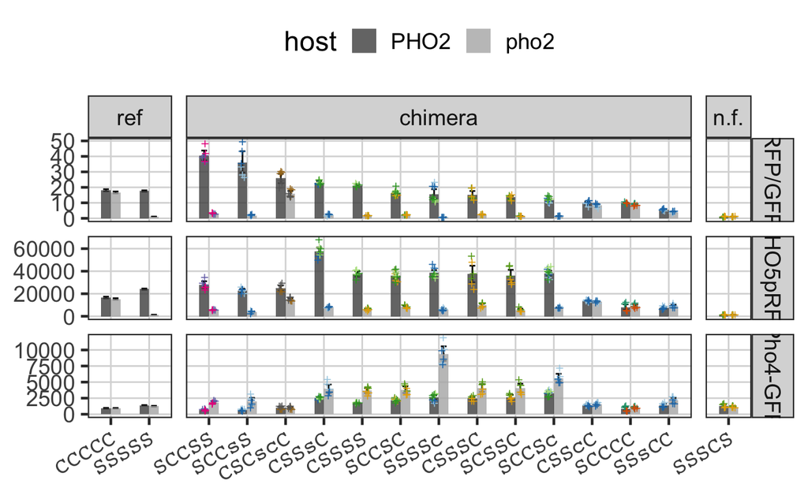

```r
p <- my_plot_ratio(c(refs,day.var.gfp.list))# +
p
```

High day-to-day GFP variance: 212, 222, 229, 231, 241, 251, 252, 277, 301, 326, 328, 329, 331, 334 High day-to-day RFP variance: 212, 216, 239, 241

Plotting components for chimeras with high day-to-day variance in Pho4-mNeon

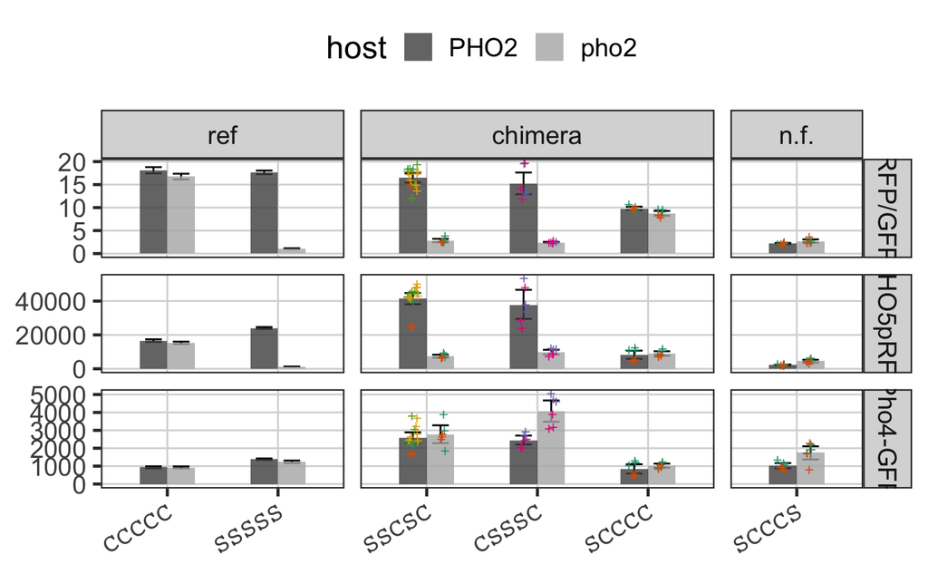

```r
p <- my_plot_ratio(c(refs,day.var.rfp.list))
p
```

> Watch out for CSCscC, SCCsS, SCCsS

Plotting components for chimeras with high day-to-day variance in *PHO5pr*-mCherry

```r
my_scatter_plot_fix <- function(){
  # this function is the same as the one in the script file, but is used to
  # plot region 4 effects alone, and doesn't take any input
  s1 = my_data_select(pattern = "XXXCCX")
  s2 = my_data_select(pattern = "XXXSSX")
  scatter.colors = c("ScPho4" = "forestgreen", "CgPho4" = "blue3",
                     "P2ID:Cg" = "deepskyblue", "P2ID:Sc" = "palegreen2",
                     "P2ID:mixed" = "gray20")
  scatter.size = c("ScPho4" = 3.5, "CgPho4" = 3.5,
                     "P2ID:Cg" = 2.5, "P2ID:Sc" = 2.5, "P2ID:mixed" = 2.5)
  p <- ximera %>%
    # exclude the alternative break point sets "A" and "B"
    # in particular, pH294 is an alternative break point CCCcs, where P2ID:Cg
    # extends to aa 270 instead of 458. it has nearly the same activities as
    # CgPho4. However, the CCCCS in the main set has significantly reduced
    # activities both with and without Pho4. We later tested whether the
    # additional P2ID:Cg4 rescues the effect (see Cg4ext below) and it didn't
    # so far, this seems to be an one-off. we need to further investigate its
    # activities.
    filter(set %in% c("M", "S")) %>%
    mutate(A_PHO2 = signif(A_PHO2, digits = 2),
           A_pho2 = signif(A_pho2, digits = 2),
           group = case_when(
             symbol == "CCCCC" ~ "CgPho4",
             symbol == "SSSSS" ~ "ScPho4",
             plasmid %in% s1 ~ "P2ID:Cg",
             plasmid %in% s2 ~ "P2ID:Sc",
             .default = "P2ID:mixed"
           ),
           group = fct_relevel(group, names(scatter.colors))) %>%
    ggplot(aes(x = A_PHO2, y = A_pho2, label = symbol)) +
    geom_abline(slope = 1) +
    geom_point(aes(color = group, size = group)) +
    scale_color_manual(NULL, values = scatter.colors) +
    scale_size_manual(values = scatter.size, guide = "none") +
    labs(x = bquote(A[PHO2]), y = bquote(A[pho2*Delta])) +
    theme_cowplot() + panel_border(color = "gray30", size = 1.2) +
    theme(legend.text = element_text(size = rel(0.8)),
          legend.position = c(0.03, 0.83),
          axis.title = element_text(face = 2, size = rel(1.2)),
          axis.line = element_blank())
  return(p)
}
```

> most of the day-to-day variance are canceled out after RFP/GFP normalization

## All chimera, scatter plot

Plot all chimeras, coloring based on P2ID source

```r
p <- my_scatter_plot_fix()
ggsave(filename = "../img/20240308-all-chimera-scatter-color-by-P2ID.png",
       plot = p, width = 4.5, height = 4, dpi = 300)
ggplotly(p + labs(x = "A<sub>PHO2</sub>", y = "A<sub>pho2</sub>") +
           theme_gray(base_size = 16) +
           theme(legend.text = element_markdown()),
         tooltip = c("label", "x", "y"))
```

[interactive chart not shown]

```r
my_scatter_plot_all <- function(){
  # this function is the same as my_scatter_plot_fix except that it plots all the chimeras
  # without coloring them differently. for figure 5
  s1 = my_data_select(pattern = "XXXCCX")
  s2 = my_data_select(pattern = "XXXSSX")
  scatter.colors = c("ScPho4" = "forestgreen", "CgPho4" = "blue3",
                     "P2ID:Cg" = "gray20", "P2ID:Sc" = "gray20",
                     "P2ID:mixed" = "gray20")
  scatter.size = c("ScPho4" = 3.5, "CgPho4" = 3.5,
                   "P2ID:Cg" = 2.5, "P2ID:Sc" = 2.5, "P2ID:mixed" = 2.5)
  p <- ximera %>%
    filter(set %in% c("M", "S")) %>%
    mutate(A_PHO2 = signif(A_PHO2, digits = 2),
           A_pho2 = signif(A_pho2, digits = 2),
           group = case_when(
             symbol == "CCCCC" ~ "CgPho4",
             symbol == "SSSSS" ~ "ScPho4",
             plasmid %in% s1 ~ "P2ID:Cg",
             plasmid %in% s2 ~ "P2ID:Sc",
             .default = "P2ID:mixed"
           ),
           group = fct_relevel(group, names(scatter.colors))) %>%
    ggplot(aes(x = A_PHO2, y = A_pho2, label = symbol)) +
    geom_abline(slope = 1) +
    geom_point(aes(color = group, size = group)) +
    scale_color_manual(NULL, values = scatter.colors) +
    scale_size_manual(values = scatter.size, guide = "none") +
    labs(x = bquote(A[PHO2]), y = bquote(A[pho2])) +
    theme_cowplot() + panel_border(color = "gray30", size = 1.2) +
    theme(legend.text = element_text(size = rel(0.8)),
          legend.position = "none",
          axis.title = element_text(face = 2, size = rel(1.2)),
          axis.line = element_blank())

  return(p)
}
```

this function is the same as my_scatter_plot_fix except that it plots all the chimeras without coloring them differently. for figure 5

[interactive chart not shown]

Plot all chimeras, for Fig. 5

```r
my_plot_subset_ximera <- function(symbols){
  # this function plots a subset of the chimeras as horizontal bar plots
  # showing the Rel. A_PHO2 and %A_pho2∆ values
  # it takes as input a vector containing the symbols for the chimeras for
  # plotting. the order in the vector determines the plot order
  # the endogenous ScPho4 and CgPho4 are implied
  missing <- setdiff(symbols, ximera$symbol)
  if(length(missing) != 0)
    stop(paste(missing, "are not found", sep = " "))

  tmp <- filter(ximera, symbol %in% c("SSSSS", "CCCCC", symbols)) %>%
    mutate(
      rSE_PHO2 = se_PHO2 / A_PHO2[symbol == "SSSSS"],
      rSE_pho2 = se_pho2 / A_pho2[symbol == "SSSSS"]
    ) %>%
    pivot_longer(cols = c(rA_PHO2, rA_pho2, rSE_PHO2, rSE_pho2),
                 #pivot_longer(cols = c(A_PHO2, A_pho2, se_PHO2, se_pho2),
                 names_to = c(".value", "parameter"), names_sep = "_",
                 values_to = "value") %>%
    mutate(parameter = fct_relevel(parameter, "PHO2"),
           symbol = factor(symbol, levels =
                             unique(c("SSSSS", "CCCCC", symbols)))) %>%
    select(-c(A_PHO2:boost))

  # labeller
  par.explain <- c(
    PHO2 = "Rel. A<sub>PHO2</sub>",
    #boost = "Boost",
    pho2 = "Rel. A<sub>pho2∆</sub>"
  )

  p <- ggplot(tmp, aes(y = symbol, x = rA)) +
    geom_col(width = 0.5, color = "black", fill = "gray80") +
    geom_vline(xintercept = 1, linetype = 2, color = "gray30") +
    geom_errorbar(aes(xmin = rA - rSE, xmax = rA + rSE), width = 0.2) +
    facet_wrap(~parameter, scales = "free_x",# switch = "x",
              labeller = labeller(parameter = par.explain)) +
    scale_y_discrete(limits = rev) +
    scale_x_continuous(expand = expansion(mult = c(0.02, 0.05))) +
    theme_cowplot() + panel_border(color = "gray30") +
    background_grid(major = "y", minor = "none") +
    theme(axis.text.y = element_text(family = "courier"),
          axis.title = element_blank(),
          axis.line = element_blank(),
          strip.placement = "outside",
          strip.background = element_blank(),
          strip.text = element_markdown())
  return(p)
}
```

## Spotlight individual chimeras

The goal here is to plot individual chimeras in order to test specific hypotheses and make certain points.

1. We separately tested and found that CgPho4 DBD binds the consensus DNA more strongly than ScPho4 does, and it also has two additional activation booster regions, which enhance the activity of the main AD. We therefore hypothesize that by replacing the corresponding regions in ScPho4 with the parts from CgPho4, we would create a chimeric TF that is not or far less dependent on Pho2.
2. We also expect that those regions additively contribute to the reduced Pho2-dependence, shown as increased TF activity of the chimera in the *pho2∆* background.

Design plot

```r
my_plot_subset_ximera_alt <- function(symbols){
  # this function plots a subset of the chimeras as horizontal bar plots
  # showing the Rel. A_PHO2 and %A_pho2∆ values
  # it takes as input a vector containing the symbols for the chimeras for
  # plotting. the order in the vector determines the plot order
  # the endogenous ScPho4 and CgPho4 are implied
  missing <- setdiff(symbols, ximera$symbol)
  if(length(missing) != 0)
    stop(paste(missing, "are not found", sep = " "))

  tmp <- filter(dat_sep, symbol %in% c("SSSSS", "CCCCC", symbols)) %>%
    mutate(host = fct_relevel(host, "PHO2"),
           symbol = factor(symbol, levels =
                             unique(c("SSSSS", "CCCCC", symbols))))

  tmp %>% count(symbol, host) %>% print()
  # labeller
  par.explain <- c(
    PHO2 = "A<sub>PHO2</sub>",
    #boost = "Boost",
    pho2 = "A<sub>pho2∆</sub>"
  )

  p <- ggplot(tmp, aes(y = symbol, x = A)) +
    geom_bar(stat = "summary", fun = "mean",
             width = 0.5, color = "black", fill = "gray80") +
    stat_summary(fun.data = "mean_cl_boot", geom = "linerange",
                 color = "steelblue4") +
    geom_point(data = filter(tmp, !symbol %in% c("CCCCC", "SSSSS")),
               size = 0.6, shape = 3, color = "gray30") +
    #geom_vline(xintercept = 1, linetype = 2, color = "gray30") +
    #geom_errorbar(aes(xmin = rA - rSE, xmax = rA + rSE), width = 0.2) +
    facet_wrap(~host, scales = "free_x",# switch = "x",
              labeller = labeller(host = par.explain)) +
    scale_y_discrete(limits = rev) +
    scale_x_continuous(expand = expansion(mult = c(0.02, 0.05))) +
    theme_cowplot() + panel_border(color = "gray30") +
    background_grid(major = "y", minor = "none") +
    theme(axis.text.y = element_text(family = "courier"),
          axis.title = element_blank(),
          axis.line = element_blank(),
          strip.placement = "outside",
          strip.background = element_blank(),
          strip.text = element_markdown())
  return(list(data = tmp, plot = p))
}
```

Update 2024-11-22

Alternative design, with individual points and not relative to ScPho4. Also, individual datapoints were plotted for samples with <10 replicates

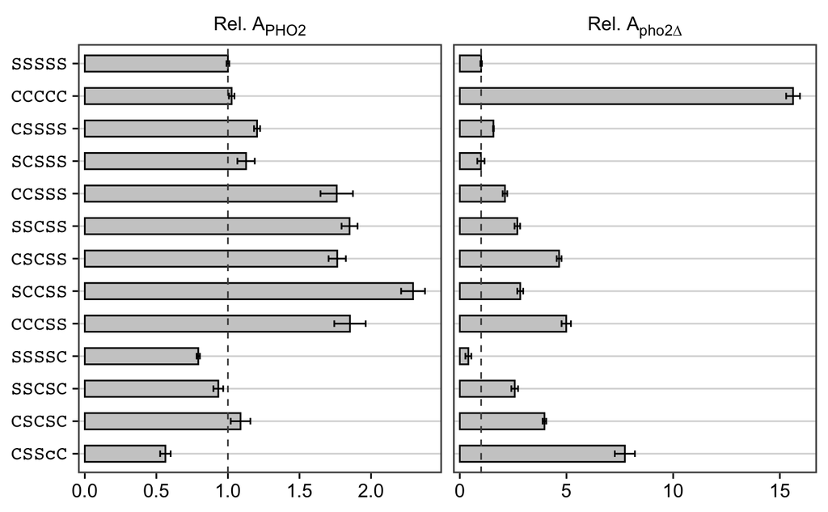

```r
selected <- as.character(
  expression(CSSSS, SCSSS, CCSSS, SSCSS, CSCSS, SCCSS, CCCSS, SSSSC, SSCSC, CSCSC, CSScC))
#selected <- filter(meta, symbol %in% selected) %>% pull(plasmid)
my_plot_subset_ximera(selected)
ggsave("../img/20240308-selected-chimera-rel-activity.png", width = 4, height = 4)
```

```r
# plot with absolute A not relative, and plot individual data points
plot.sub1 <- my_plot_subset_ximera_alt(selected)
```

| symbol | host | n |
| --- | --- | --- |
| SSSSS | PHO2 | 144 |
| SSSSS | pho2 | 36 |
| CCCCC | PHO2 | 36 |
| CCCCC | pho2 | 36 |
| CSSSS | PHO2 | 6 |
| CSSSS | pho2 | 6 |
| SCSSS | PHO2 | 6 |
| SCSSS | pho2 | 6 |
| CCSSS | PHO2 | 5 |
| CCSSS | pho2 | 6 |

[output cut: 16 more lines]

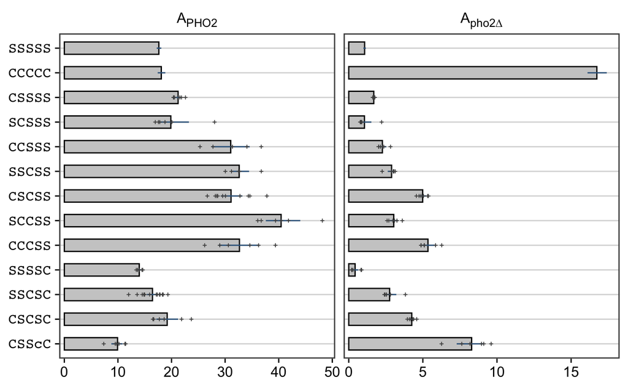

```r
print(plot.sub1$plot)
ggsave("../img/20241122-selected-chimera-rel-activity.png", width = 4, height = 4)
```

```r
# save the data for publication
plot.sub1$data %>%
  select(plasmid_id = plasmid, chimera_makeup = symbol, host, A) %>%
  write_tsv("../output/20250213-Fig-5C-data.tsv")
```

### Minimal CgPho4 parts for A_pho2

```r
# select the chimeras
selected <- as.character(
  expression(SSSSS, CSSSS, SCSSS, SSCSS, CCSSS, CSCSS, SCCSS, CCCSS)
)

# extract the data
tmp <- ximera %>%
  filter(symbol %in% selected, set == "M") %>%
  select(plasmid, symbol, group) %>%
  inner_join(dat, by = "plasmid") %>%
  mutate( `R/G` = YL2.H / BL1.H ) %>%
  filter(flag == "pass") %>%
  select(-nRFP, -nGFP, -well, -flag)

# prepare the factor levels
split <- c(1,1,1,2); names(split) <- c("R1", "AD", "NLS")

tmp <- tmp %>%
  separate_wider_position(symbol, split) %>%
  mutate(across(R1:NLS, ~factor(.x, levels = c("S", "C"))))

# test A_PHO2
print("Testing A_PHO2")
```

```
[1] "Testing A_PHO2"
```

```r
lm.res <- tmp %>%
  filter(host == "PHO2") %>%
  lm(`R/G` ~ (R1*AD*NLS), data = .) %>%
  summary()
# adding adjusted P-value
lm.res$coefficients <- cbind(
  coef(lm.res),
  "P.adj" = p.adjust(coef(lm.res)[,'Pr(>|t|)'], method = "holm")
)
print(lm.res)
```

```
Call:
lm(formula = `R/G` ~ (R1 * AD * NLS), data = .)

Residuals:
    Min      1Q  Median      3Q     Max
-6.4865 -1.6014 -0.5069  1.0472 12.7647

Coefficients:
                Estimate  Std. Error     t value    Pr(>|t|) P.adj
(Intercept)    1.764e+01   2.391e-01   7.375e+01  5.546e-137 0.000
R1C            3.591e+00   1.196e+00   3.004e+00   3.046e-03 0.012
ADC            2.237e+00   1.196e+00   1.871e+00   6.296e-02 0.063
NLSC           1.499e+01   1.196e+00   1.254e+01   2.350e-26 0.000
R1C:ADC        7.578e+00   2.109e+00   3.593e+00   4.213e-04 0.002
R1C:NLSC      -5.110e+00   1.904e+00  -2.684e+00   7.959e-03 0.021
ADC:NLSC       5.586e+00   2.043e+00   2.734e+00   6.873e-03 0.021
R1C:ADC:NLSC  -1.383e+01   3.064e+00  -4.514e+00   1.142e-05 0.000

Residual standard error: 2.869 on 181 degrees of freedom
Multiple R-squared:  0.825, Adjusted R-squared:  0.8182
F-statistic: 121.9 on 7 and 181 DF,  p-value: < 2.2e-16
```

```r
# store the test results for plotting
res.PHO2 <- coef(lm.res)[-1,] %>% as_tibble(rownames = "component")

# test A_pho2
print("Testing A_pho2∆")
```

```
[1] "Testing A_pho2∆"
```

```r
lm.res <- tmp %>%
  filter(host == "pho2") %>%
  lm(`R/G` ~ (R1*AD*NLS), data = .) %>%
  summary()
# adding adjusted P-value
lm.res$coefficients <- cbind(
  coef(lm.res),
  "P.adj" = p.adjust(coef(lm.res)[,'Pr(>|t|)'], method = "holm")
)
print(lm.res)
```

```
Call:
lm(formula = `R/G` ~ (R1 * AD * NLS), data = .)

Residuals:
     Min       1Q   Median       3Q      Max
-0.63622 -0.21548 -0.01744  0.10489  1.15930

Coefficients:
               Estimate Std. Error    t value   Pr(>|t|) P.adj
(Intercept)   1.072e+00  5.581e-02  1.920e+01  1.312e-29  0.00
R1C           6.167e-01  1.477e-01  4.176e+00  8.404e-05  0.00
ADC          -1.153e-02  1.477e-01 -7.805e-02  9.380e-01  1.00
NLSC          1.819e+00  1.477e-01  1.232e+01  3.389e-19  0.00
R1C:ADC       5.923e-01  2.433e-01  2.435e+00  1.746e-02  0.07
R1C:NLSC      1.479e+00  2.433e-01  6.081e+00  5.623e-08  0.00
ADC:NLSC      1.575e-01  2.433e-01  6.475e-01  5.194e-01  1.00
R1C:ADC:NLSC -3.795e-01  3.660e-01 -1.037e+00  3.033e-01  0.91

Residual standard error: 0.3349 on 70 degrees of freedom
Multiple R-squared:  0.9553,    Adjusted R-squared:  0.9509
F-statistic: 213.9 on 7 and 70 DF,  p-value: < 2.2e-16
```

```r
# store the test results for plotting
res.pho2 <- coef(lm.res)[-1,] %>% as_tibble(rownames = "component")

# combine the results
test.res <- bind_rows(
  "A_PHO2" = res.PHO2, "A_pho2" = res.pho2, .id = "parameter"
)

# save the output in a text file for paper
write_tsv(test.res, file = "../output/20250213-region-1-3-linear-model-test.txt")
```

### Region 1-3 main effects and interactions

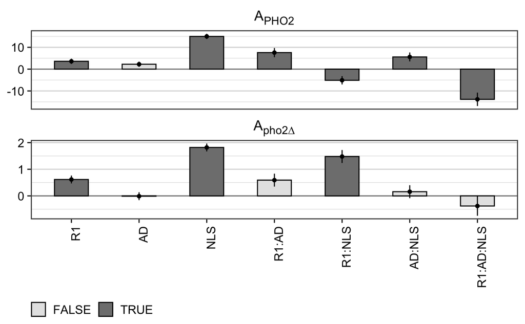

```r
par.explain <- c(
  A_PHO2 = "A<sub>PHO2</sub>",
  A_pho2 = "A<sub>pho2∆</sub>"
)

p <- test.res %>%
  rename(estimate = Estimate, se = `Std. Error`) %>%
  mutate(
    component = gsub("C", "", component) %>% fct_inorder(),
    parameter = factor(parameter, levels = c("A_PHO2", "A_pho2")),
    sig = P.adj < 0.05
  ) %>%
  ggplot(aes(x = component, y = estimate)) +
  geom_hline(yintercept = 0, linetype = 1, color = "gray50") +
  geom_col(aes(fill = P.adj < 0.05), width = 0.5, color = "black") +
  geom_pointrange(aes(ymin = estimate-se, ymax = estimate+se), size = 0.2) +
  facet_wrap(~parameter, scales = "free_y", nrow = 2,
             labeller = labeller(parameter = par.explain)) +
  scale_x_discrete() +
  scale_y_continuous() +
  scale_fill_manual(NULL,
                    values = c("gray90", "gray50")) +
  theme_cowplot() + panel_border(color = "gray30") +
  background_grid(major = "y", minor = "y") +
  theme(axis.text.x = element_text(angle = 90, hjust = 1, size = rel(1)),
        axis.title = element_blank(),
        axis.line = element_blank(),
        legend.position = "bottom",
        strip.placement = "outside",
        strip.background = element_blank(),
        strip.text = element_markdown(size = rel(1)))
p
ggsave("../img/20240404-region1-3-epistasis-plot.png", width = 3.5, height = 4.5)
```

Plot the result

```r
selected <- as.character(
  expression(CCCSC, CCCcsC, CCCscC, CSSCC, CSSSC, CSScsC, CSSscC))
#selected <- filter(meta, symbol %in% selected) %>% pull(plasmid)
plot.sub2 <- my_plot_subset_ximera_alt(selected)
```

| symbol | host | n |
| --- | --- | --- |
| SSSSS | PHO2 | 144 |
| SSSSS | pho2 | 36 |
| CCCCC | PHO2 | 36 |
| CCCCC | pho2 | 36 |
| CCCSC | PHO2 | 6 |
| CCCSC | pho2 | 6 |
| CCCcsC | PHO2 | 6 |
| CCCcsC | pho2 | 6 |
| CCCscC | PHO2 | 6 |
| CCCscC | pho2 | 6 |

[output cut: 8 more lines]

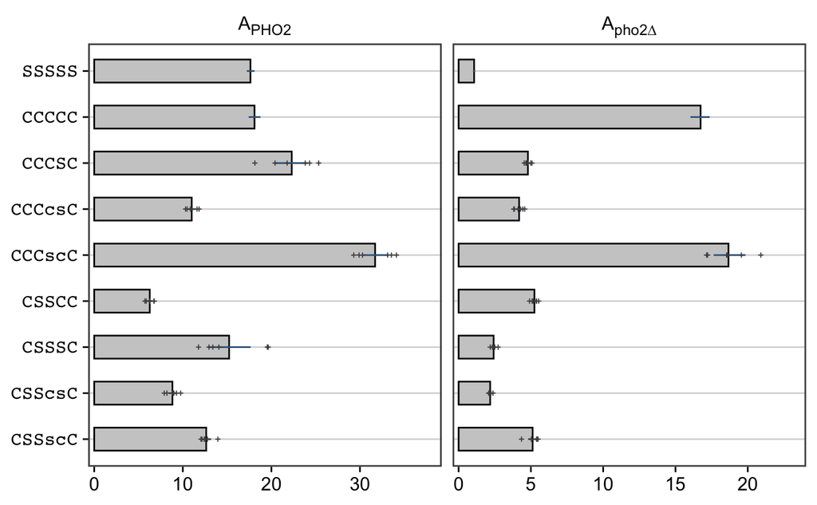

```r
plot.sub2$plot + scale_x_continuous(expand = expansion(mult = c(0.02, 0.15)))
ggsave("../img/20241122-P2ID-split-rel-activity.png", width = 3.5, height = 3.5)
```

```r
plot.sub2$data %>%
  select(plasmid_id = plasmid, chimera_makeup = symbol, host, A) %>%
  write_tsv("../output/20250213-Fig-6B-data.tsv")
```

### Region 4 splits

We have so far focused on the main set with the 5 region design. In the scatter plot below, we see that there is a subset of chimeras in between the P2ID:Sc and P2ID:Cg ones. They are interesting in that their A_pho2∆/A_PHO2 ratios are intermediate.

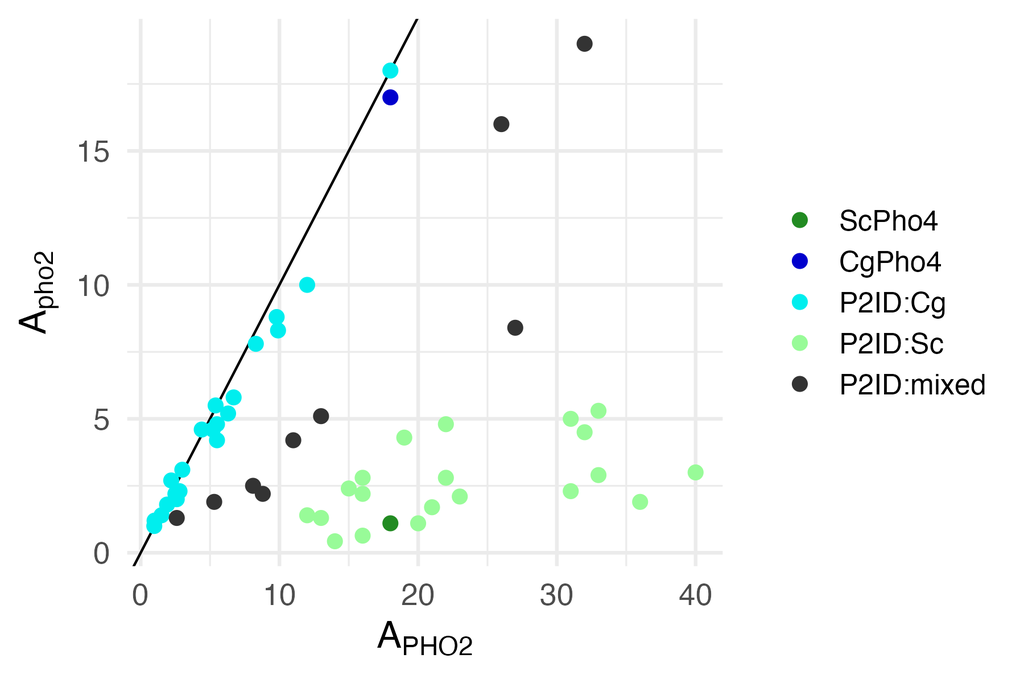

scatter

```r
# select the chimeras
selected <- as.character(
  expression(CCCCC, CCCSC, CCCcsC, CCCscC)
)

# extract the data
tmp <- ximera %>%
  filter(symbol %in% selected) %>%
  select(plasmid, symbol, group) %>%
  inner_join(dat, by = "plasmid") %>%
  mutate( `R/G` = YL2.H / BL1.H ) %>%
  filter(flag == "pass") %>%
  select(-nRFP, -nGFP, -well, -flag) %>%
  mutate(symbol = factor(symbol, levels = !!selected))

# test A_PHO2
print("Testing A_PHO2")
```

```
[1] "Testing A_PHO2"
```

```r
lm.res <- tmp %>%
  filter(host == "PHO2") %>%
  lm(`R/G` ~ symbol, data = .) %>%
  summary()
# adding adjusted P-value
lm.res$coefficients <- cbind(
  coef(lm.res),
  "P.adj" = p.adjust(coef(lm.res)[,'Pr(>|t|)'], method = "holm")
)
print(lm.res)
```

```
Call:
lm(formula = `R/G` ~ symbol, data = .)

Residuals:
    Min      1Q  Median      3Q     Max
-5.2250 -1.0489 -0.0647  1.2813  6.6290

Coefficients:
               Estimate Std. Error    t value   Pr(>|t|) P.adj
(Intercept)   1.809e+01  3.445e-01  5.252e+01  2.067e-45     0
symbolCCCSC   4.207e+00  9.115e-01  4.615e+00  2.766e-05     0
symbolCCCcsC -7.086e+00  9.115e-01 -7.774e+00  3.722e-10     0
symbolCCCscC  1.362e+01  9.115e-01  1.494e+01  4.511e-20     0

Residual standard error: 2.067 on 50 degrees of freedom
Multiple R-squared:  0.8711,    Adjusted R-squared:  0.8633
F-statistic: 112.6 on 3 and 50 DF,  p-value: < 2.2e-16
```

```r
# store the test results for plotting
#res.PHO2 <- coef(lm.res)[-1,] %>% as_tibble(rownames = "component")

# test A_pho2
print("Testing A_pho2∆")
```

```
[1] "Testing A_pho2∆"
```

```r
lm.res <- tmp %>%
  filter(host == "pho2") %>%
  lm(`R/G` ~ symbol, data = .) %>%
  summary()
# adding adjusted P-value
lm.res$coefficients <- cbind(
  coef(lm.res),
  "P.adj" = p.adjust(coef(lm.res)[,'Pr(>|t|)'], method = "holm")
)
print(lm.res)
```

```
Call:
lm(formula = `R/G` ~ symbol, data = .)

Residuals:
    Min      1Q  Median      3Q     Max
-5.1275 -0.5912 -0.0824  0.5645  5.2165

Coefficients:
               Estimate Std. Error    t value   Pr(>|t|) P.adj
(Intercept)   1.674e+01  2.869e-01  5.834e+01  1.176e-47 0.000
symbolCCCSC  -1.195e+01  7.591e-01 -1.574e+01  5.226e-21 0.000
symbolCCCcsC -1.255e+01  7.591e-01 -1.654e+01  6.456e-22 0.000
symbolCCCscC  1.928e+00  7.591e-01  2.540e+00  1.424e-02 0.014

Residual standard error: 1.721 on 50 degrees of freedom
Multiple R-squared:  0.9093,    Adjusted R-squared:  0.9038
F-statistic:   167 on 3 and 50 DF,  p-value: < 2.2e-16
```

Statistical tests for group 1

```r
# select the chimeras
selected <- as.character(
  expression( CSSCC, CSSSC, CSScsC, CSSscC )
)

# extract the data
tmp <- ximera %>%
  filter(symbol %in% selected) %>%
  select(plasmid, symbol, group) %>%
  inner_join(dat, by = "plasmid") %>%
  mutate( `R/G` = YL2.H / BL1.H ) %>%
  filter(flag == "pass") %>%
  select(-nRFP, -nGFP, -well, -flag) %>%
  mutate(symbol = factor(symbol, levels = !!selected))

# test A_PHO2
print("Testing A_PHO2")
```

```
[1] "Testing A_PHO2"
```

```r
lm.res <- tmp %>%
  filter(host == "PHO2") %>%
  lm(`R/G` ~ symbol, data = .) %>%
  summary()
# adding adjusted P-value
lm.res$coefficients <- cbind(
  coef(lm.res),
  "P.adj" = p.adjust(coef(lm.res)[,'Pr(>|t|)'], method = "holm")
)
print(lm.res)
```

```
Call:
lm(formula = `R/G` ~ symbol, data = .)

Residuals:
    Min      1Q  Median      3Q     Max
-3.4560 -0.5974 -0.1128  0.4629  4.4143

Coefficients:
              Estimate Std. Error   t value  Pr(>|t|) P.adj
(Intercept)  6.270e+00  7.393e-01 8.481e+00 4.673e-08 0.000
symbolCSSSC  8.962e+00  1.046e+00 8.572e+00 3.949e-08 0.000
symbolCSScsC 2.558e+00  1.046e+00 2.447e+00 2.378e-02 0.024
symbolCSSscC 6.372e+00  1.046e+00 6.094e+00 5.891e-06 0.000

Residual standard error: 1.811 on 20 degrees of freedom
Multiple R-squared:  0.8127,    Adjusted R-squared:  0.7846
F-statistic: 28.93 on 3 and 20 DF,  p-value: 1.791e-07
```

```r
# store the test results for plotting
#res.PHO2 <- coef(lm.res)[-1,] %>% as_tibble(rownames = "component")

# test A_pho2
print("Testing A_pho2∆")
```

```
[1] "Testing A_pho2∆"
```

```r
lm.res <- tmp %>%
  filter(host == "pho2") %>%
  lm(`R/G` ~ symbol, data = .) %>%
  summary()
# adding adjusted P-value
lm.res$coefficients <- cbind(
  coef(lm.res),
  "P.adj" = p.adjust(coef(lm.res)[,'Pr(>|t|)'], method = "holm")
)
print(lm.res)
```

```
Call:
lm(formula = `R/G` ~ symbol, data = .)

Residuals:
     Min       1Q   Median       3Q      Max
-0.77040 -0.08856 -0.03391  0.16099  0.37316

Coefficients:
               Estimate Std. Error    t value   Pr(>|t|) P.adj
(Intercept)   5.244e+00  1.082e-01  4.846e+01  3.257e-22 0.000
symbolCSSSC  -2.822e+00  1.530e-01 -1.844e+01  5.058e-14 0.000
symbolCSScsC -3.061e+00  1.530e-01 -2.000e+01  1.076e-14 0.000
symbolCSSscC -1.243e-01  1.530e-01 -8.125e-01  4.261e-01 0.426

Residual standard error: 0.265 on 20 degrees of freedom
Multiple R-squared:  0.9726,    Adjusted R-squared:  0.9685
F-statistic: 237.1 on 3 and 20 DF,  p-value: 8.565e-16
```

Statistical tests for group 2

```r
split <- c(1,1,1,1,1); names(split) <- paste0("P", 1:5)
tmp <- ximera %>%
  filter(set == "M", group != "n.f.") %>%
  separate_wider_position(symbol, split) %>%
  mutate(across(P1:P5, ~factor(.x, levels = c("S", "C"))))
lm <- lm(A_pho2 ~ (P1+P2+P3+P4+P5), data = tmp)
summary(lm)
```

```
Call:
lm(formula = A_pho2 ~ (P1 + P2 + P3 + P4 + P5), data = tmp)

Residuals:
    Min      1Q  Median      3Q     Max
-3.5062 -1.1430 -0.0082  0.8638  6.5285

Coefficients:
            Estimate Std. Error t value Pr(>|t|)
(Intercept)  -0.7264     1.0811  -0.672   0.5102
P1C           2.3316     0.8687   2.684   0.0152 *
P2C           0.7880     0.8687   0.907   0.3763
P3C           2.5260     0.9010   2.804   0.0117 *
P4C           4.0647     0.9792   4.151   0.0006 ***
P5C           1.2254     0.9010   1.360   0.1906
---
Signif. codes:  0 ‘***’ 0.001 ‘**’ 0.01 ‘*’ 0.05 ‘.’ 0.1 ‘ ’ 1

Residual standard error: 2.086 on 18 degrees of freedom
Multiple R-squared:  0.7398,    Adjusted R-squared:  0.6675
F-statistic: 10.23 on 5 and 18 DF,  p-value: 9.054e-05
```